## 空間分析 期末考

#### 助教 杜承軒 2020.06.14

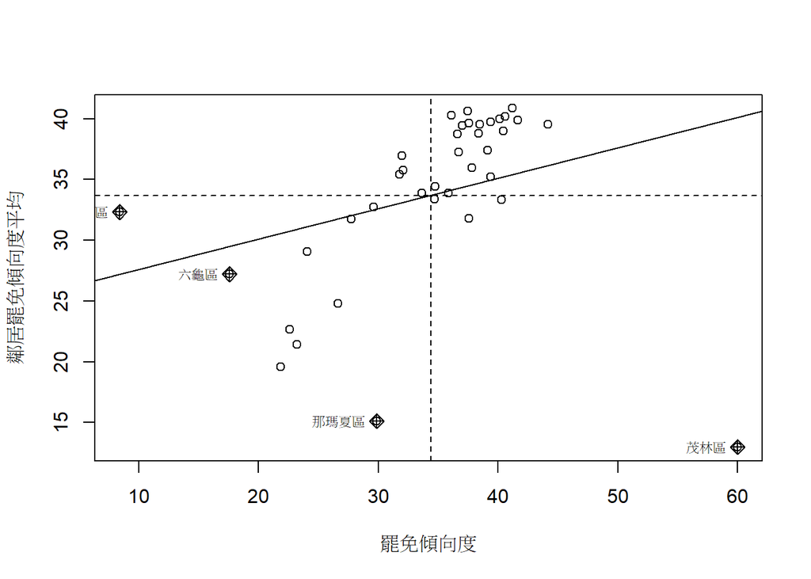

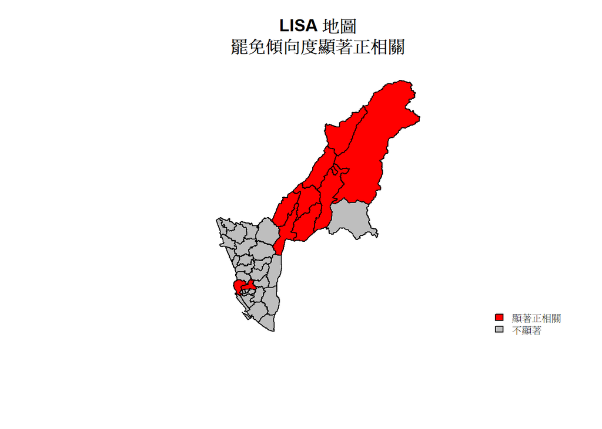

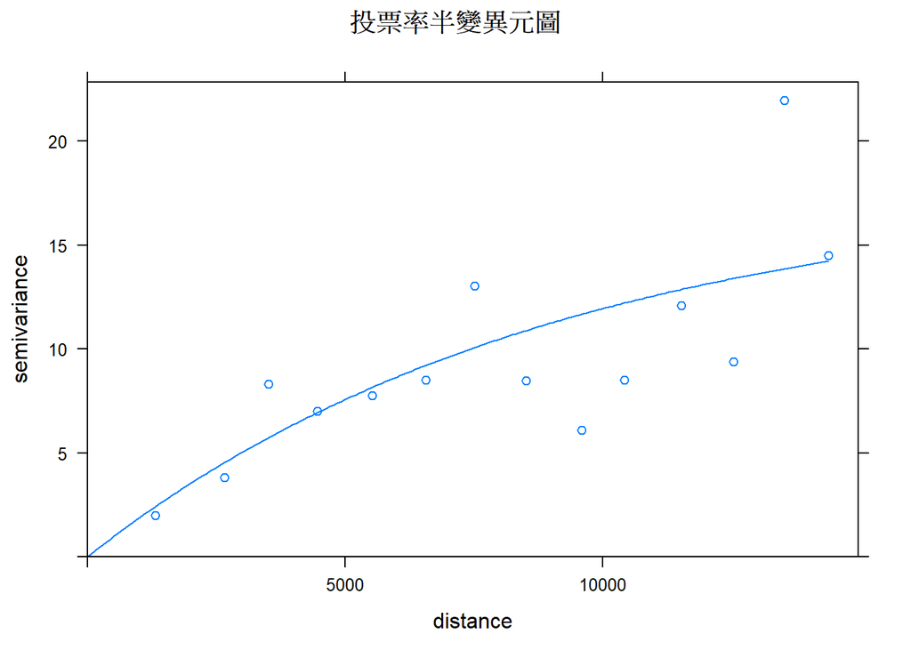

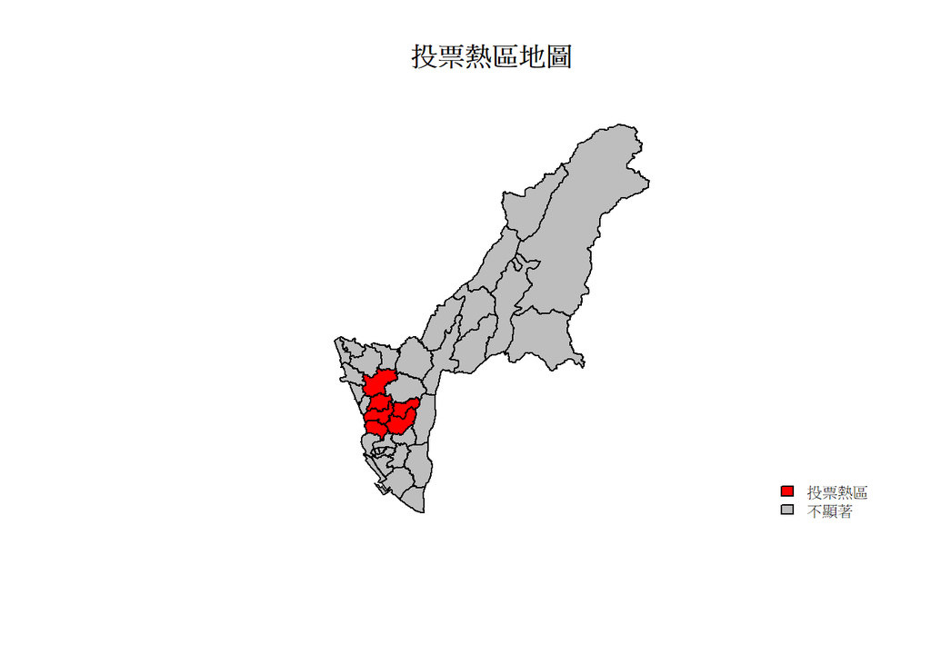